# ScPCA Benchmarking: Run Time and Memory Comparison

This notebook compares the run time and memory footprint of pre-processing 4 scRNA-seq samples across 4 different tools. We used cellranger v6, kallisto, alevin, and alevin-fry. Alevin-fry was used with and without `--sketch` mode and/or `--unfiltered-pl`. The purpose of this notebook is to gain an understanding on how much time and memory each of the tools uses. We are starting with looking at 4 scRNA-seq samples and 2 snRNA-seq samples. The snRNA-seq samples have been run with 2 different indices, cDNA and pre-mRNA.

```r
library(tidyverse)
library(rjson)
```

```r
## set up file paths
base_dir <- getwd()

logs_dir <- file.path(base_dir, "nextflow_logs")
alevin_dir <- file.path(logs_dir, "alevin-quant", "alevin")
kallisto_dir <- file.path(logs_dir, "kallisto-quant")
cellranger_dir <- file.path(logs_dir, "cellranger-quant")
alevin_fry_dir <- file.path(logs_dir, "alevin-quant", "alevin-fry")
alevin_fry_sketch_dir <- file.path(logs_dir, "alevin-quant", "alevin-fry-sketch")
alevin_fry_unfiltered_dir <- file.path(logs_dir, "alevin-quant", "alevin-fry-unfiltered")
alevin_fry_unfiltered_sketch_dir <- file.path(logs_dir, "alevin-quant", "alevin-fry-unfiltered-sketch")
```

```r
# setup directories and paths for kallisto logs

data_dir <- file.path(base_dir, 'data', 'quants')
dir.create(data_dir, recursive = TRUE, showWarnings = FALSE)

kallisto_quants_dir <- file.path(data_dir, 'kallisto')
dir.create(kallisto_quants_dir, recursive = TRUE, showWarnings = FALSE)
quant_s3_kallisto <- 's3://nextflow-ccdl-results/scpca/kallisto-quant'
```

```r
# get log files from S3
# include json file from each kallisto run
samples <- c('SCPCR000003', 'SCPCR000006', 'SCPCR000118', 'SCPCR000119', 'SCPCR000126', 'SCPCR000127')

includes <- stringr::str_glue("--include \"*/{samples}\"")

sync_call <- paste('aws s3 sync', quant_s3_kallisto, kallisto_quants_dir,
                   includes,'--exclude "*/bus/*"', '--exclude "*/counts/*"',
                   '--include "*/bus/run_info.json"')
system(sync_call, ignore.stdout = TRUE)
```

For each run, we asked nextflow to ouput a trace.txt txt file using the -with-trace flag. These [trace files](https://www.nextflow.io/docs/latest/tracing.html) include important information about each process such as run time and memory.

Let’s make a function to read in the trace files for each of the tools. Each tool and configuration has it’s own working directory with three trace.txt files: one containing the run for scRNA samples, one for the snRNA samples with the mRNA index, and one for the snRNA samples with the pre-mRNA index.

```r
make_trace_df <- function(workdir, file_ext = ".trace.txt", tool){
  workdir_files <- list.files(workdir)
  names(workdir_files) <- gsub(file_ext, "", workdir_files)
  workdir_df <- purrr::map_dfr(workdir_files,
                              ~ readr::read_tsv(file.path(workdir, .x), col_types = cols()),
                              .id = "file_base") %>%
    dplyr::mutate(Tool = tool)
}
```

## Alevin

```r
alevin_trace_df <- make_trace_df(alevin_dir,
                                 ".trace.txt",
                                 tool = "Alevin")
```

## Alevin Fry

```r
alevin_fry_trace_df <- make_trace_df(alevin_fry_dir,
                                     ".trace.txt",
                                     tool = "Alevin-Fry")
```

```r
# alevin fry sketch
alevin_fry_sketch_trace_df <- make_trace_df(alevin_fry_sketch_dir,
                                            ".sketch.trace.txt",
                                            tool = "Alevin-Fry-Sketch")
```

```r
# alevin fry unfiltered
alevin_fry_unfiltered_trace_df <- make_trace_df(alevin_fry_unfiltered_dir,
                                                ".unfiltered.trace.txt",
                                                tool = "Alevin-Fry-Unfiltered")
```

```r
# alevin fry unfiltered sketch
alevin_fry_unfiltered_sketch_trace_df <- make_trace_df(alevin_fry_unfiltered_sketch_dir,
                                                       ".unfiltered.sketch.trace.txt",
                                                       tool = "Alevin-Fry-Unfiltered-Sketch")
```

## Kallisto

```r
kallisto_trace_df <- make_trace_df(kallisto_dir,
                                   ".trace.txt",
                                   tool = "Kallisto")
```

## CellRanger

```r
cellranger_trace_df <- make_trace_df(cellranger_dir,
                                     ".trace.txt",
                                     tool = "Cellranger")
```

## Run time comparison

```r
## first make a joint dataframe
all_trace <- bind_rows(list(alevin_trace_df, alevin_fry_trace_df,
                            alevin_fry_sketch_trace_df, alevin_fry_unfiltered_trace_df,
                            alevin_fry_unfiltered_sketch_trace_df, kallisto_trace_df,
                            cellranger_trace_df))
all_trace
```

| file_base | task_id | hash | native_id | name | status | exit | submit | duration | realtime | %cpu | peak_rss | peak_vmem | rchar | wchar | Tool |
| --- | --- | --- | --- | --- | --- | --- | --- | --- | --- | --- | --- | --- | --- | --- | --- |
| alevin.scRNA | 1 | 12/293638 | 46877d6e-d8d9-4177-8483-129cc2195adb | alevin (SCPCR000003-txome_k31_full_sa) | COMPLETED | 0 | 2021-04-08 09:09:08 | 45m 52s | 40m 28s | 533.2% | 17.9 GB | 26.1 GB | 44.8 GB | 33.5 MB | Alevin |
| alevin.scRNA | 1 | 75/446d86 | 1d88db9e-3c1d-43ac-81fb-e5d1d3ad6dcd | alevin (SCPCR000006-txome_k31_full_sa) | COMPLETED | 0 | 2021-04-08 10:00:00 | 1h 5m 8s | 1h 27s | 567.8% | 19.6 GB | 22.9 GB | 36.1 GB | 58.5 MB | Alevin |
| alevin.scRNA | 1 | e7/17f0d9 | cf947f55-def1-4364-ba43-cb793c42ac58 | alevin (SCPCR000126-txome_k31_full_sa) | COMPLETED | 0 | 2021-04-08 13:59:06 | 37m 7s | 31m 30s | 454.0% | 19.9 GB | 24.1 GB | 41.7 GB | 126.2 MB | Alevin |
| alevin.scRNA | 1 | 94/362448 | 3405dbe3-02ae-4b32-9b28-c91d24e7fa04 | alevin (SCPCR000127-txome_k31_full_sa) | COMPLETED | 0 | 2021-04-08 14:45:48 | 43m 38s | 37m 49s | 497.8% | 20.7 GB | 24.6 GB | 42.6 GB | 132.9 MB | Alevin |
| alevin.snRNA.intron | 2 | 4e/3f242e | a883c6a3-f6b3-4354-97ab-c666546add41 | alevin (SCPCR000119-spliced_intron_txome_k31_full_sa) | COMPLETED | 0 | 2021-04-26 12:30:08 | 22m 7s | 17m 36s | 209.8% | 22.1 GB | 29.9 GB | 42.3 GB | 217.4 MB | Alevin |
| alevin.snRNA.intron | 1 | bb/661103 | f7114cae-8ddb-4e9f-b83d-52118ff9db50 | alevin (SCPCR000118-spliced_intron_txome_k31_full_sa) | COMPLETED | 0 | 2021-04-26 12:30:08 | 25m 47s | 21m 6s | 143.7% | 21.8 GB | 29.4 GB | 44.3 GB | 180.2 MB | Alevin |
| alevin.snRNA | 2 | 2c/8b0b81 | 85c624ae-2903-4b64-88c7-85f01642da77 | alevin (SCPCR000119-spliced_txome_k31_full_sa) | COMPLETED | 0 | 2021-04-26 15:17:03 | 21m 27s | 16m 58s | 194.5% | 17.9 GB | 22 GB | 38.4 GB | 2.4 MB | Alevin |
| alevin.snRNA | 1 | 13/10b091 | a829f10a-a0c9-463d-be1c-3a4afad4658d | alevin (SCPCR000118-spliced_txome_k31_full_sa) | COMPLETED | 0 | 2021-04-26 15:17:03 | 25m 7s | 20m 36s | 140.1% | 17.7 GB | 21.7 GB | 40.4 GB | 2 MB | Alevin |
| alevin.fry.scRNA | 1 | f2/ea5ad7 | afbf77fa-c1bd-4da9-9bac-b626140626c1 | alevin (SCPCR000003-txome_k31) | COMPLETED | 0 | 2021-04-09 09:20:21 | 25m 57s | 20m 10s | 756.0% | 1.5 GB | 2.7 GB | 19 GB | 1.5 GB | Alevin-Fry |
| alevin.fry.scRNA | 5 | 5a/e2a094 | ef7d3e69-306e-4017-a815-595de5e0c300 | generate_permit (SCPCR000003-txome_k31) | COMPLETED | 0 | 2021-04-09 09:46:19 | 1m 19s | 27.1s | 63.0% | 52.7 MB | 399.3 MB | 1.5 GB | 21.1 MB | Alevin-Fry |

[output cut: 158 more lines]

We need to do some manipulation to this data frame to the peak_rss and realtime columns so they are all in the right units and of class(numeric) for plotting.

```r
## now separate the columns by process and sample_id to make cleaner for plotting
all_trace <- all_trace %>%
  separate(name, into = c("process", "sample_id"), sep = " ") %>%
  separate(sample_id, into = c("sample_id", "index_name"), sep = "-")

all_trace$sample_id = gsub("[()]", "", all_trace$sample_id)
all_trace$index_name = gsub("[()]", "", all_trace$index_name)

## make separate column for either GB or MB for peak_rss
all_trace <- all_trace %>%
  separate(peak_rss, into = c("peak_rss", "rss_units"), sep = " ") %>%
  mutate(peak_rss = as.numeric(peak_rss)) %>%
  mutate(peak_rss = case_when(rss_units == "MB" ~ (peak_rss/1000),
         TRUE ~ peak_rss))


## convert from hours, minutes, to seconds
all_trace <- all_trace %>%
  mutate(hours = str_extract(all_trace$duration, "\\d+h"),
         minutes = str_extract(all_trace$duration, "\\d+m"),
         seconds = str_extract(all_trace$duration, "\\d+s")) %>%
  mutate(hours = gsub("h", "", hours),
         minutes = gsub("m", "", minutes),
         seconds = gsub("s", "", seconds)) %>%
  mutate(hours = as.numeric(hours),
         minutes = as.numeric(minutes),
         seconds = as.numeric(seconds))
all_trace$hours[is.na(all_trace$hours)] = 0
all_trace$minutes[is.na(all_trace$minutes)] = 0
all_trace$seconds[is.na(all_trace$seconds)] = 0

all_trace <- all_trace %>%
  mutate(total_time = hours*60 + minutes + seconds/60)
all_trace
```

| file_base | task_id | hash | native_id | process | sample_id | index_name | status | exit | submit | duration | realtime | %cpu | peak_rss | rss_units | peak_vmem | rchar | wchar | Tool | hours | minutes | seconds | total_time |
| --- | --- | --- | --- | --- | --- | --- | --- | --- | --- | --- | --- | --- | --- | --- | --- | --- | --- | --- | --- | --- | --- | --- |
| alevin.scRNA | 1 | 12/293638 | 46877d6e-d8d9-4177-8483-129cc2195adb | alevin | SCPCR000003 | txome_k31_full_sa | COMPLETED | 0 | 2021-04-08 09:09:08 | 45m 52s | 40m 28s | 533.2% | 17.9000 | GB | 26.1 GB | 44.8 GB | 33.5 MB | Alevin | 0 | 45 | 52 | 45.86666667 |
| alevin.scRNA | 1 | 75/446d86 | 1d88db9e-3c1d-43ac-81fb-e5d1d3ad6dcd | alevin | SCPCR000006 | txome_k31_full_sa | COMPLETED | 0 | 2021-04-08 10:00:00 | 1h 5m 8s | 1h 27s | 567.8% | 19.6000 | GB | 22.9 GB | 36.1 GB | 58.5 MB | Alevin | 1 | 5 | 8 | 65.13333333 |
| alevin.scRNA | 1 | e7/17f0d9 | cf947f55-def1-4364-ba43-cb793c42ac58 | alevin | SCPCR000126 | txome_k31_full_sa | COMPLETED | 0 | 2021-04-08 13:59:06 | 37m 7s | 31m 30s | 454.0% | 19.9000 | GB | 24.1 GB | 41.7 GB | 126.2 MB | Alevin | 0 | 37 | 7 | 37.11666667 |
| alevin.scRNA | 1 | 94/362448 | 3405dbe3-02ae-4b32-9b28-c91d24e7fa04 | alevin | SCPCR000127 | txome_k31_full_sa | COMPLETED | 0 | 2021-04-08 14:45:48 | 43m 38s | 37m 49s | 497.8% | 20.7000 | GB | 24.6 GB | 42.6 GB | 132.9 MB | Alevin | 0 | 43 | 38 | 43.63333333 |
| alevin.snRNA.intron | 2 | 4e/3f242e | a883c6a3-f6b3-4354-97ab-c666546add41 | alevin | SCPCR000119 | spliced_intron_txome_k31_full_sa | COMPLETED | 0 | 2021-04-26 12:30:08 | 22m 7s | 17m 36s | 209.8% | 22.1000 | GB | 29.9 GB | 42.3 GB | 217.4 MB | Alevin | 0 | 22 | 7 | 22.11666667 |
| alevin.snRNA.intron | 1 | bb/661103 | f7114cae-8ddb-4e9f-b83d-52118ff9db50 | alevin | SCPCR000118 | spliced_intron_txome_k31_full_sa | COMPLETED | 0 | 2021-04-26 12:30:08 | 25m 47s | 21m 6s | 143.7% | 21.8000 | GB | 29.4 GB | 44.3 GB | 180.2 MB | Alevin | 0 | 25 | 47 | 25.78333333 |
| alevin.snRNA | 2 | 2c/8b0b81 | 85c624ae-2903-4b64-88c7-85f01642da77 | alevin | SCPCR000119 | spliced_txome_k31_full_sa | COMPLETED | 0 | 2021-04-26 15:17:03 | 21m 27s | 16m 58s | 194.5% | 17.9000 | GB | 22 GB | 38.4 GB | 2.4 MB | Alevin | 0 | 21 | 27 | 21.45000000 |
| alevin.snRNA | 1 | 13/10b091 | a829f10a-a0c9-463d-be1c-3a4afad4658d | alevin | SCPCR000118 | spliced_txome_k31_full_sa | COMPLETED | 0 | 2021-04-26 15:17:03 | 25m 7s | 20m 36s | 140.1% | 17.7000 | GB | 21.7 GB | 40.4 GB | 2 MB | Alevin | 0 | 25 | 7 | 25.11666667 |
| alevin.fry.scRNA | 1 | f2/ea5ad7 | afbf77fa-c1bd-4da9-9bac-b626140626c1 | alevin | SCPCR000003 | txome_k31 | COMPLETED | 0 | 2021-04-09 09:20:21 | 25m 57s | 20m 10s | 756.0% | 1.5000 | GB | 2.7 GB | 19 GB | 1.5 GB | Alevin-Fry | 0 | 25 | 57 | 25.95000000 |
| alevin.fry.scRNA | 5 | 5a/e2a094 | ef7d3e69-306e-4017-a815-595de5e0c300 | generate_permit | SCPCR000003 | txome_k31 | COMPLETED | 0 | 2021-04-09 09:46:19 | 1m 19s | 27.1s | 63.0% | 0.0527 | MB | 399.3 MB | 1.5 GB | 21.1 MB | Alevin-Fry | 0 | 1 | 19 | 1.31666667 |

[output cut: 158 more lines]

We will also want to compare the number of reads in each sample to the memory/runtime so let’s add in that information.

```r
## add in number of reads/ sample
## found in individual logfiles from kallisto
single_cell_samples <- c('SCPCR000003', 'SCPCR000006', 'SCPCR000126', 'SCPCR000127')

all_trace$Reads = 0
for (sample in samples) {
  if(sample %in% single_cell_samples){
    # only samples that are single cell were run with this index
    sample_file <- paste0(sample, "-txome_k31")
  }
  else {
    # single nuclei samples have the spliced intron ending for the file name
    sample_file <- paste0(sample, "-spliced_intron_txome_k31")
  }
  # read in run_info.json log from each kallisto run
  log <- fromJSON(file = file.path(kallisto_quants_dir, sample_file,
                                 "bus", "run_info.json"))
  #n_processed gives amount of reads for each sample
  all_trace[which(all_trace$sample_id == sample), "Reads"] <- log$n_processed
}
```

Let’s also add in a column about sequencing unit so we can separate out those samples later on. To do that, we need the `scpca-library-metadata.tsv` file from s3.

```r
# add in library metadata for each sample
library_data_dir <- file.path(base_dir, 'sample-info')
dir.create(library_data_dir, recursive = TRUE, showWarnings = FALSE)
sample_info_dir_s3 <- 's3://ccdl-scpca-data/sample_info'

# grab library metadata from location in s3
sync_call <- paste('aws s3 sync', sample_info_dir_s3, library_data_dir,
                   '--exclude "*"',
                   '--include "*scpca-library-metadata.tsv"')
system(sync_call, ignore.stdout = TRUE)
```

```r
# read in sample metadata
library_df <- readr::read_tsv(file.path(library_data_dir, "scpca-library-metadata.tsv"))
```

```r
# filter data frame with information that might be relevant for looking at these samples
select_metadata_df <- library_df %>%
  dplyr::select(scpca_run_id, scpca_sample_id, seq_unit, technology)
```

```r
# make combined df with technology and seq unit
all_trace_comb <- all_trace %>%
  left_join(select_metadata_df, by = c("sample_id" = "scpca_run_id"))
```

```r
# create a summary data frame that merges total time and memory for all steps
summary_stats_df <- all_trace_comb %>%
  group_by(Tool, seq_unit, sample_id, index_name) %>%
  summarise(total_time = sum(total_time),
            total_rss = sum(peak_rss),
            Reads = mean(Reads))
summary_stats_df
```

| Tool | seq_unit | sample_id | index_name | total_time | total_rss | Reads |
| --- | --- | --- | --- | --- | --- | --- |
| Alevin | cell | SCPCR000003 | txome_k31_full_sa | 45.86667 | 17.9000 | 118642093 |
| Alevin | cell | SCPCR000006 | txome_k31_full_sa | 65.13333 | 19.6000 | 76264542 |
| Alevin | cell | SCPCR000126 | txome_k31_full_sa | 37.11667 | 19.9000 | 298134261 |
| Alevin | cell | SCPCR000127 | txome_k31_full_sa | 43.63333 | 20.7000 | 308129889 |
| Alevin | nucleus | SCPCR000118 | spliced_intron_txome_k31_full_sa | 25.78333 | 21.8000 | 366909948 |
| Alevin | nucleus | SCPCR000118 | spliced_txome_k31_full_sa | 25.11667 | 17.7000 | 366909948 |
| Alevin | nucleus | SCPCR000119 | spliced_intron_txome_k31_full_sa | 22.11667 | 22.1000 | 286347287 |
| Alevin | nucleus | SCPCR000119 | spliced_txome_k31_full_sa | 21.45000 | 17.9000 | 286347287 |
| Alevin-Fry | cell | SCPCR000003 | txome_k31 | 31.23333 | 3.2306 | 118642093 |
| Alevin-Fry | cell | SCPCR000006 | txome_k31 | 49.13333 | 3.0636 | 76264542 |

[output cut: 44 more lines]

## Time and Memory with Sample ID on x-axis

Let’s first look at the runtime for only the single cell samples and then single nuclei samples separately. I know from running them, that the snRNA-seq samples took much longer to run so I want to look at each tool with each type of sample separately.

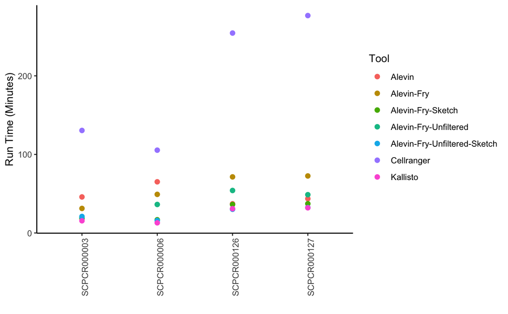

```r
ggplot(summary_stats_df %>%
         dplyr::filter(seq_unit == "cell"),
       aes(x = sample_id, y = total_time, color = Tool)) +
  geom_point(size = 2) +
  theme_classic() +
  xlab("") +
  ylab("Run Time (Minutes)") +
  theme(axis.text.x = element_text(angle = 90, hjust = 1))
```

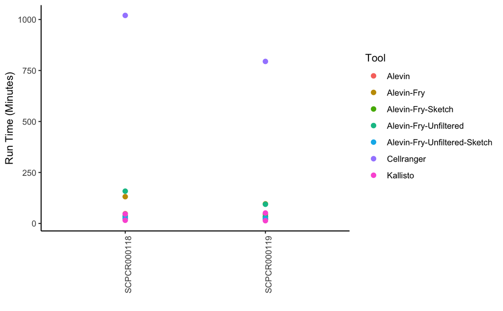

```r
ggplot(summary_stats_df %>%
         dplyr::filter(seq_unit == "nucleus"),
       aes(x = sample_id, y = total_time, color = Tool)) +
  geom_point(size = 2) +
  theme_classic() +
  xlab("") +
  ylab("Run Time (Minutes)") +
  theme(axis.text.x = element_text(angle = 90, hjust = 1))
```

Now, let’s look at all the samples together across all the tools and do we see any differences across the tools?

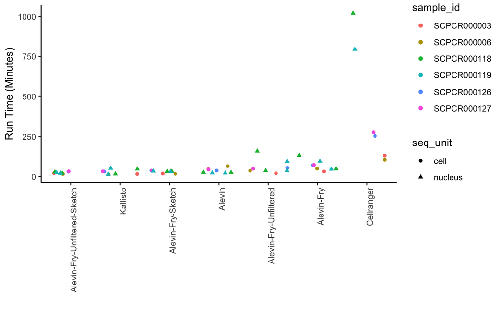

```r
# another way to visualize it if we want to group all the samples together
summary_stats_df %>%
  # order the plot by the median runtime
  mutate(Tool = fct_reorder(Tool, total_time, .fun = 'median')) %>%
  ggplot(aes(x = reorder(Tool, total_time), y = total_time)) +
  geom_jitter(mapping = aes(color = sample_id, shape = seq_unit)) +
  theme_classic() +
  xlab("") +
  ylab("Run Time (Minutes)") +
  theme(axis.text.x = element_text(angle = 90, hjust = 1))
```

From the runtime plots, it’s clear that cellranger has an increase in runtime with single-nuclei samples, while other tools don’t seem to be affected by the single-nuclei samples.

The variation in cellranger is making the y-axis in this plot really high. Let’s see if we can get more granular when looking at the other tools, by removing cellranger.

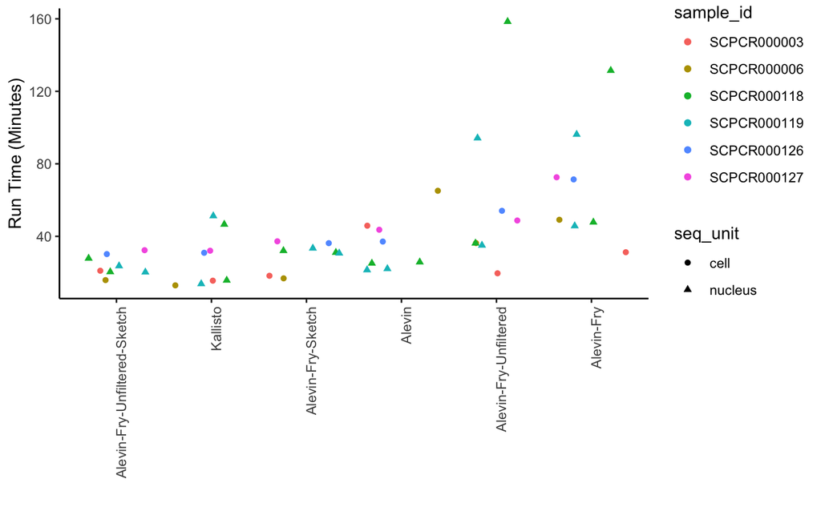

```r
summary_stats_df %>%
  dplyr::filter(Tool != "Cellranger") %>%
  # order the plot by the median runtime
  mutate(Tool = fct_reorder(Tool, total_time, .fun = 'median')) %>%
  ggplot(aes(x = reorder(Tool, total_time), y = total_time)) +
  geom_jitter(mapping = aes(color = sample_id, shape = seq_unit)) +
  theme_classic() +
  xlab("") +
  ylab("Run Time (Minutes)") +
  theme(axis.text.x = element_text(angle = 90, hjust = 1))
```

Now we can start to see the differences in the other tools. We also see that alevin-fry-unfiltered-sketch, kallisto and alevin-fry-sketch are fairly similar. Although, it does appear that there is a slight preference for higher run time in kallisto with 2 of the single-nuclei samples. That same runtime increase for single-nuclei samples is seen in Alevin-fry-unfiltered and alevin-fry, but not in sketch mode. These samples were run with two different indices, so which 2 snRNA-seq samples are those? Let’s break this up based on the index type.

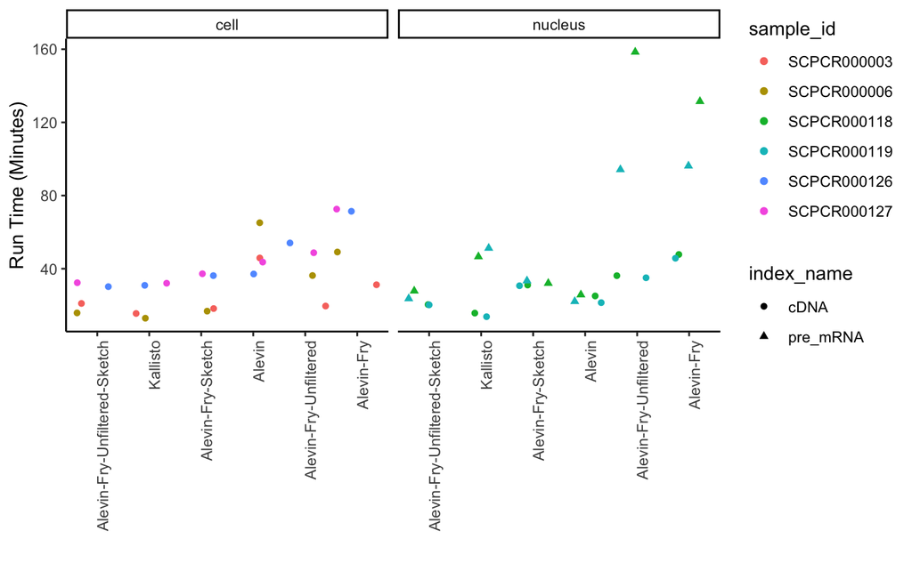

```r
# rename index names so they are in one of two groups, pre_mRNA or cDNA
summary_stats_df <- summary_stats_df %>%
  mutate(index_name = ifelse(index_name %in% c("spliced_intron_txome_k31", "spliced_intron_txome_k31_full_sa"),
                             "pre_mRNA", "cDNA"))


summary_stats_df %>%
  dplyr::filter(Tool != "Cellranger") %>%
  # order the plot by the median runtime
  mutate(Tool = fct_reorder(Tool, total_time, .fun = 'median')) %>%
  ggplot(aes(x = reorder(Tool, total_time), y = total_time)) +
  geom_jitter(mapping = aes(color = sample_id, shape = index_name)) +
  theme_classic() +
  facet_grid(~seq_unit) +
  xlab("") +
  ylab("Run Time (Minutes)") +
  theme(axis.text.x = element_text(angle = 90, hjust = 1))
```

Now, we are breaking this up by cell and nucleus. We can see that if we look at the nucleus samples, that kallisto, Alevin-fry-unfiltered and alevin-fry show a clear separation between single-nuclei samples run with cDNA and pre-mRNA. This is important because based on the counts data, the pre_mRNA index is beneficial to quantification and thus these tools will have an increased run time for these samples.

Now, let’s look at memory usage.

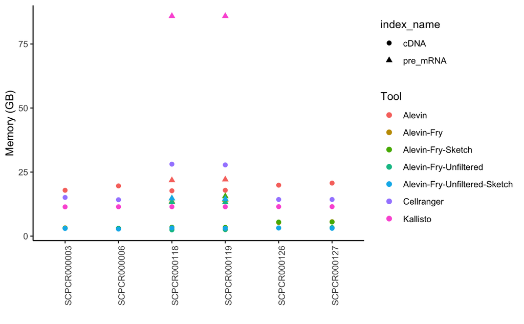

```r
ggplot(summary_stats_df, aes(x = sample_id, y = total_rss, color = Tool, shape = index_name)) +
  geom_point(size = 2) +
  theme_classic() +
  xlab("") +
  ylab("Memory (GB)") +
  theme(axis.text.x = element_text(angle = 90, hjust = 1))
```

Right away, we can see the large increase in memory that Kallisto uses for single-nuclei samples run with the pre-mRNA index. We can also see that Alevin and Cellranger are generally high in terms of memory usage while Alevin-Fry remains the lowest.

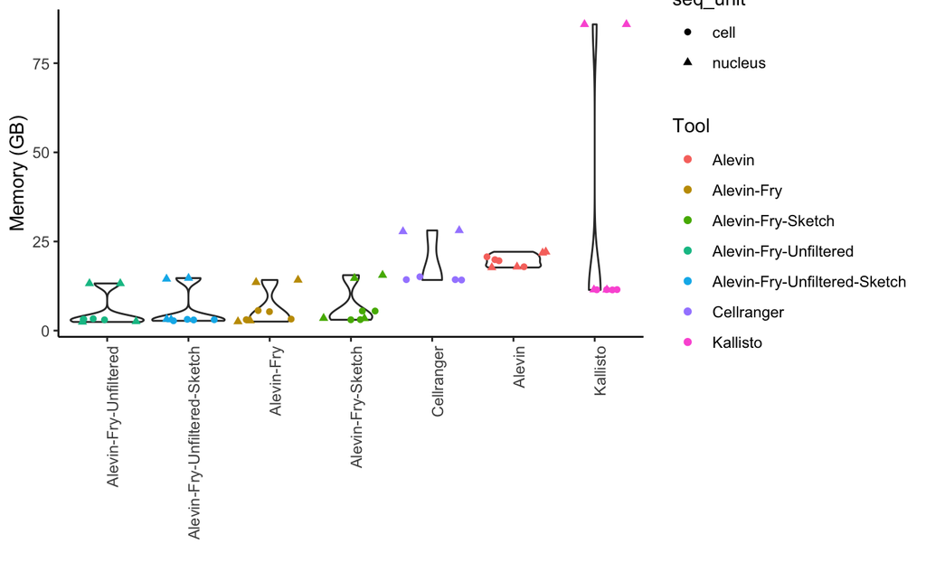

```r
# another way to visualize it if we want to group all the samples together
summary_stats_df %>%
  mutate(Tool = fct_reorder(Tool, total_rss, .fun = 'median')) %>%
  ggplot(aes(x = reorder(Tool, total_rss), y = total_rss)) +
  geom_violin() +
  geom_jitter(mapping = aes(color = Tool, shape = seq_unit)) +
  theme_classic() +
  xlab("") +
  ylab("Memory (GB)") +
  theme(axis.text.x = element_text(angle = 90, hjust = 1))
```

When we look at this plot, you can now see again the huge jump in Kallisto, but it appears that alot of the tools have a difference in memory usage in single-nuclei samples vs. single-cell samples, where the single-nuclei samples require much more memory to process.

Let’s zoom in on just the alevin tools.

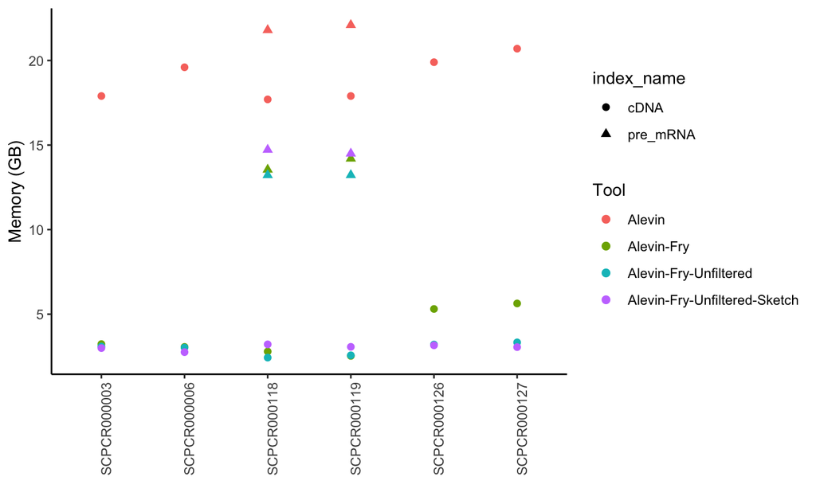

```r
# Just alevin tools to compare better across those
# run time
alevin_tools = c("Alevin","Alevin-Fry", "Alevin-Fry-Unfiltered", "Alevin-Fry-Unfiltered-Sketch")

ggplot(summary_stats_df %>%
         dplyr::filter(Tool %in% alevin_tools),
       aes(x = sample_id, y = total_rss, color = Tool, shape = index_name)) +
  geom_point(size = 2) +
  theme_classic() +
  xlab("") +
  ylab("Memory (GB)") +
  theme(axis.text.x = element_text(angle = 90, hjust = 1))
```

Within the alevin tools, you can see that the snRNA-seq samples with the pre mRNA index definitely use more memory in general. However, alevin vs. alevin-fry generally uses much more memory.

Next, let’s see if the number of reads in each fastq file impacts the runtime and/or memory usage.

## Time and Memory vs. # of Reads

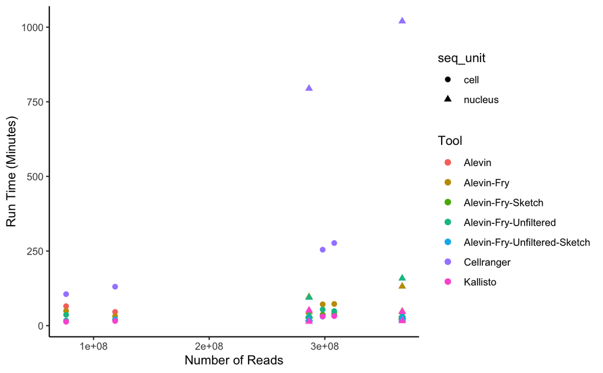

```r
# run time vs. # of fastq reads
ggplot(summary_stats_df, aes(x = Reads, y = total_time, color = Tool)) +
  geom_point(size = 2, mapping = aes(shape = seq_unit)) +
  theme_classic() +
  xlab("Number of Reads") +
  ylab("Run Time (Minutes)")
```

Looking at this, there is a clear increase in runtime with number of reads in cellranger, although it looks like there is a higher impact on the single-nuclei reads. If you look at the two single-cell samples with high read count that were run on cellranger vs. the two single-nuclei samples with similar read count there is a drastic increase in runtime.

Let’s remove cellranger so we can zoom in and see if that same increase is present in any of the other tools?

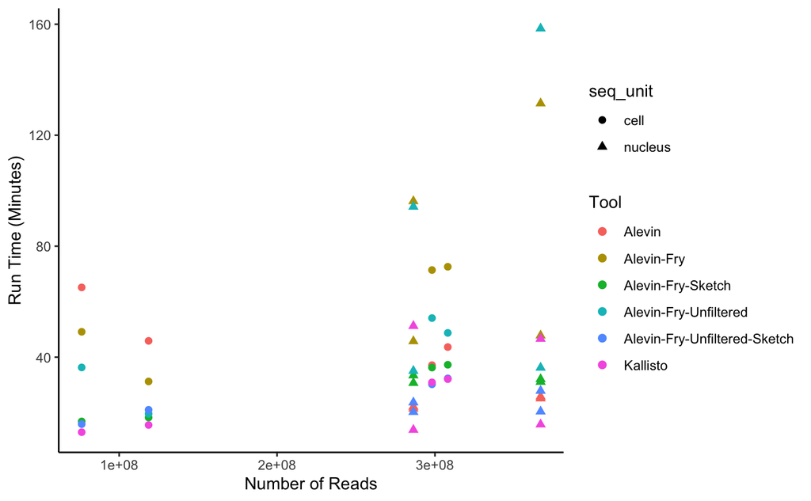

```r
# remove cellranger and look at the rest of the tools
ggplot(summary_stats_df %>%
         dplyr::filter(Tool != "Cellranger"),
       aes(x = Reads, y = total_time, color = Tool)) +
  geom_point(size = 2, mapping = aes(shape = seq_unit)) +
  theme_classic() +
  xlab("Number of Reads") +
  ylab("Run Time (Minutes)")
```

Now we can see that same increase is also present in alevin-fry-unfiltered and alevin-fry but not in `--sketch` mode. We also see that kallisto might have a slight increase in time dependent on read number in single-cell too and a further increase with single-nuclei.

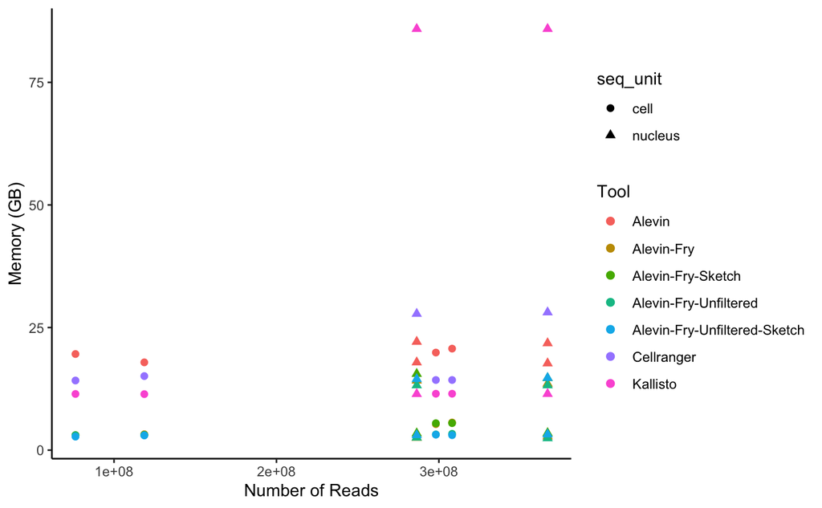

```r
ggplot(summary_stats_df, aes(x = Reads, y = total_rss, color = Tool)) +
  geom_point(size = 2, mapping = aes(shape = seq_unit)) +
  theme_classic() +
  xlab("Number of Reads") +
  ylab("Memory (GB)")
```

Again, we see that increase in kallisto with single nuclei samples, but this seems independent of number of reads. It looks like cellranger also has that increase in single nuclei samples, again this seems independent of number of reads. None of the other tools appear to have memory changes based on the number of reads.

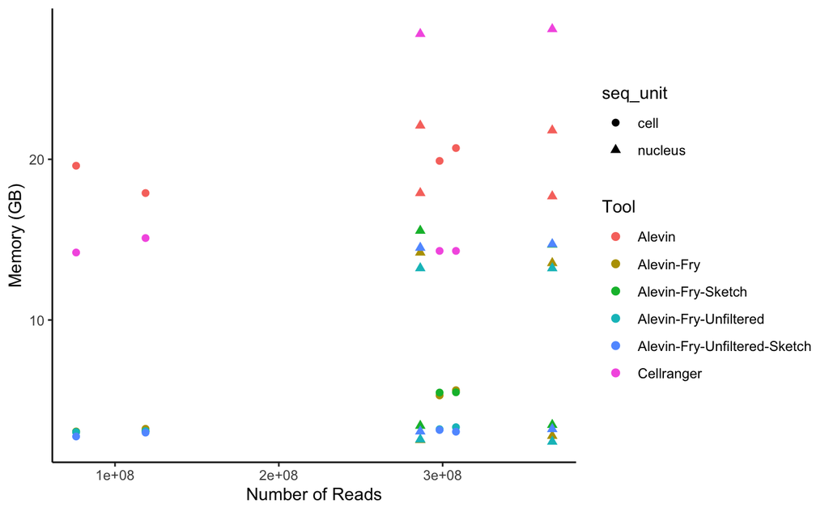

```r
# remove kallisto to zoom in on the other tools
ggplot(summary_stats_df %>%
         dplyr::filter(Tool != "Kallisto"),
       aes(x = Reads, y = total_rss, color = Tool)) +
  geom_point(size = 2, mapping = aes(shape = seq_unit)) +
  theme_classic() +
  xlab("Number of Reads") +
  ylab("Memory (GB)")
```

There doesn’t appear to be an effect on the memory usage based on the number of reads in the fastqs.

Some conclusions from these graphs include:

1. Cellranger has the highest run time, which is further increased with snRNA-seq samples
2. Kallisto, although a short run time in comparison to other tools, has a large increase in memory usage for snRNA-seq samples
3. In general, snRNA-seq samples use more memory than scRNA-seq
4. snRNA-seq samples have increased runtime in all but Alevin, Alevin-fry-unfiltered-sketch and alevin-fry-sketch
5. Alevin uses much more memory than all combinations of Alevin-fry tools
6. Cellranger scRNA-seq uses less memory than Alevin, but snRNA-seq uses more memory than Alevin